# One-Way ANOVA - Week 5, Lecture 1

Author

Dr. Seals

```r
library(tidyverse)
library(gsheet)
library(pgirmess)
library(car)
```

**An agricultural researcher investigated two new herbicides and their effects on crop yields of tomatoes, which can be demolished by the [tomato hornworm](https://extension.umn.edu/yard-and-garden-insects/tomato-hornworms) in mere hours. There were three areas for the experiment: an area for herbicide A, an area for herbicide B, and an area for no herbicide at all (control). At the end of the growing season, the yields (in bushels per acre) were measured and are available in the following [Google Sheet](https://docs.google.com/spreadsheets/d/1CFyuuWy-4YmVU3wkYuC8Uf3xW3qkpCnpF468NjBAhbY/edit#gid=0).**

```r
data <- as_tibble(gsheet2tbl("https://docs.google.com/spreadsheets/d/1CFyuuWy-4YmVU3wkYuC8Uf3xW3qkpCnpF468NjBAhbY/edit#gid=0"))
```

#### 1. Construct the 95% confidence interval for the average yield for each group (A, B, control).

```r
t.test(data$Herbicide1)
```

```
    One Sample t-test

data:  data$Herbicide1
t = 55.258, df = 29, p-value < 2.2e-16
alternative hypothesis: true mean is not equal to 0
95 percent confidence interval:
 82.12035 88.43299
sample estimates:
mean of x
 85.27667
```

```r
t.test(data$Herbicide2)
```

```
    One Sample t-test

data:  data$Herbicide2
t = 96.613, df = 29, p-value < 2.2e-16
alternative hypothesis: true mean is not equal to 0
95 percent confidence interval:
 88.33621 92.15712
sample estimates:
mean of x
 90.24667
```

```r
t.test(data$Control)
```

```
    One Sample t-test

data:  data$Control
t = 64.899, df = 29, p-value < 2.2e-16
alternative hypothesis: true mean is not equal to 0
95 percent confidence interval:
 84.66827 90.17840
sample estimates:
mean of x
 87.42333
```

The 95% CI for herbicide A is (82.12, 88.43).

The 95% CI for herbicide B is (88.34, 92.16).

The 95% CI for the control is (84.66, 90.18)

#### 2. Challenge! Construct a graph to display all confidence intervals.

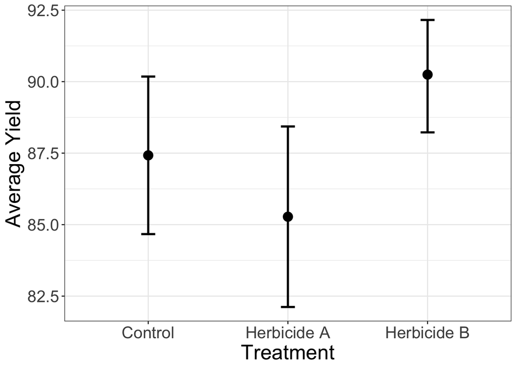

```r
group <- c("Herbicide A", "Herbicide B", "Control")
mean <- c(85.27667, 90.24667, 87.42333)
LCL <- c(82.12035, 88.22621, 84.66827)
UCL <- c(88.43299, 92.15712, 90.17840)
CI <- tibble(group, LCL, mean, UCL)

CI %>% ggplot(aes(x=factor(group), y=mean)) +
  geom_errorbar(aes(ymin=LCL, ymax=UCL), width=.1, size=1) +
  geom_point(size=4) +
  ylab("Average Yield") +
  xlab("Treatment") +
  theme_bw()+
  theme(text = element_text(size=20))
```

#### 3. Challenge! Why should we be cautious when using the individual CIs found in Q1 and displayed in Q2 to directly compare the three groups?

Because the CIs were not found simultaneously… we are inflating the type I error rate if we do not construct CIs simultaneously (i.e., spread the $\alpha$ out over the three intervals).

#### 4. Use the appropriate hypothesis test to show that there is a difference in the average yield between the three groups.

```r
long <- data %>%
  pivot_longer(cols = c("Herbicide1", "Herbicide2", "Control"),
               names_to = "Group",
               values_to = "Yield")
m1 <- aov(Yield ~ Group, data = long)
summary(m1)
```

```
            Df Sum Sq Mean Sq F value Pr(>F)
Group        2    373  186.40   3.677 0.0293 *
Residuals   87   4410   50.69
---
Signif. codes:  0 '***' 0.001 '**' 0.01 '*' 0.05 '.' 0.1 ' ' 1
```

**Hypotheses**

- $H_0: \mu_\text{A} = \mu_{\text{B}} = \mu_{\text{Ctrl}}$
- $H_1:$ at least one $\mu_i$ is different.

**Test Statistic and *p*-Value**

- $F_0=3.677$
- $p = 0.029$

**Rejection Region**

- Reject $H_0$ if $p < \alpha$; $\alpha=0.05$.

**Conclusion/Interpretation**

- Reject $H_0$ at the $\alpha=0.05$ level. There is sufficient evidence to suggest that there is at least one difference between the three treatments.

#### 5. Construct and test the following contrasts for the following comparisons:

```r
long <- long %>% mutate(Group = as.factor(Group))
contrasts(long$Group)
```

```
           Herbicide1 Herbicide2
Control             0          0
Herbicide1          1          0
Herbicide2          0          1
```

```r
contrasts(long$Group) <- cbind(c(0, 1, -1),
                               c(1, -0.5, -0.5))
contrasts(long$Group)
```

```
           [,1] [,2]
Control       0  1.0
Herbicide1    1 -0.5
Herbicide2   -1 -0.5
```

```r
summary.aov(m1, split=list(Group=list("A vs. B"=1,
                                      "A + B vs. Ctrl"=2)))
```

```
                        Df Sum Sq Mean Sq F value Pr(>F)
Group                    2    373  186.40   3.677 0.0293 *
  Group: A vs. B         1    253  253.23   4.996 0.0280 *
  Group: A + B vs. Ctrl  1    120  119.57   2.359 0.1282
Residuals               87   4410   50.69
---
Signif. codes:  0 '***' 0.001 '**' 0.01 '*' 0.05 '.' 0.1 ' ' 1
```

##### a. Herbicide A vs. Herbicide B.

**Hypotheses**

- $H_0: \mu_\text{A} = \mu_{\text{B}}$
- $H_1: \mu_\text{A} \ne \mu_{\text{B}}$

**Rejection Region**

- Reject $H_0$ if $p < \alpha$; $\alpha=0.05 \text{ and} \alpha_{\text{B}}=0.025$.

##### b. Herbicide A and Herbicide B vs. Control

**Hypotheses**

- $H_0: \mu_\text{A} + \mu_{\text{B}} = \mu_{\text{Ctrl}}$
- $H_1: \mu_\text{A} + \mu_{\text{B}} \ne \mu_{\text{Ctrl}}$.

**Test Statistic and *p*-Value**

- $F_0=2.359$
- $p = 0.128$

**Rejection Region**

- Reject $H_0$ if $p < \alpha$; $\alpha=0.05 \text{ and} \alpha_{\text{B}}=0.025$.

**Conclusion/Interpretation**

- Fail to reject $H_0$ at the $\alpha=0.05$ level. There is not sufficient evidence to suggest that herbicides A and B, together, are different from the control group.

#### 6. Use the appropriate posthoc test to perform all pairwise comparisons of yield.

```r
round(TukeyHSD(m1)$Group, 3)
```

```
                        diff    lwr   upr p adj
Herbicide1-Control    -2.147 -6.530 2.237 0.476
Herbicide2-Control     2.823 -1.560 7.207 0.279
Herbicide2-Herbicide1  4.970  0.587 9.353 0.022
```

Only herbicides 1 and 2 are different from one another. Neither herbicide is different from the control.

#### 7. Use the appropriate posthoc test to only compare the individual herbicides to the control.

```r
library(DescTools)
DunnettTest(x=long$Yield,
            g=long$Group,
            control = "Control")
```

```
  Dunnett's test for comparing several treatments with a control :
    95% family-wise confidence level

$Control
                        diff    lwr.ci   upr.ci   pval
Herbicide1-Control -2.146667 -6.280237 1.986904 0.4012
Herbicide2-Control  2.823333 -1.310237 6.956904 0.2209

---
Signif. codes:  0 '***' 0.001 '**' 0.01 '*' 0.05 '.' 0.1 ' ' 1
```

Neither herbicide is different from the control.